# Week6

Sarfaraz Ahmed

August 7, 2017

# Pre-lab 6: Medical School Quality of Life

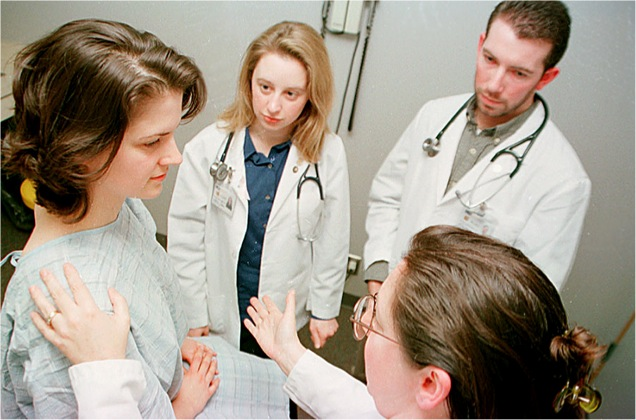

In a 2015 study, Tempski and associates examined a measurement they called Quality of Life among medical school students in Brazilian medical schools. They borrowed measurement scales from the World Health Organization, the Dundee Ready Education Environment Scale, and the Beck Depression Inventory to assess the dependent variable in potential relation to a number of predictor variables.

Primary research questions

1. Can you confirm the claim that Beck Depression Inventory score is a significant predictor of Overall Quality of Life among students enrolled in the Clinical Sciences program?
2. For students enrolled in the Clinical Sciences program, examine the effects of DREEM: Social Self Perception, DREEM: Academic Self Perception, Resilience, BDI, and Age on Med School Quality of Life?

problem 3 points possible (graded) Check the Data

Let’s begin by examining our data in R.

1. Open RStudio. Make sure you’ve installed the SDSFoundations 1.4 package.
2. Type library(SDSFoundations). This will automatically load the data for the labs. 3.Type res <- TempskiResilience. This will assign the data to your Workspace.
3. Look at the spreadsheet view of the data to answer the following questions.

Alternatively, you can use the following steps in the “Importing a Data Frame” R tutorial video, and use the TempskiResilience.csv file. (Right-click and “Save As.”) Make sure to name the dataframe “res” when importing.

1. Open RStudio.
2. Click on the “Import Dataset” button at the top of the workspace window. Choose “from text file.”
3. Click on the location of the TempskiResilience.csv file you just downloaded.
4. Click on the TempskiResilience.csv file. Then, click Upload.
5. Look at the spreadsheet view of the data to answer the following questions.

```r
library(SDSFoundations)

res <- TempskiResilience
```

1a. How many observations are in the intial dataset?

1350 correct1350 1350 1b. The first listed student with a Med School Quality of Life score of 10 is how many years old?

21 correct21 21 1c. Of the first 10 participants, how many have a Med School Quality of Life over 5?

10 incorrect7 10 Click here for a video explanation of how to answer this question. Submit You have used 1 of 1 attempt Some problems have options such as save, reset, hints, or show answer. These options follow the Submit button.

Show Answer Answers are displayed within the problem Review problem 4/4 points (graded) Check the Variables of Interest

Let’s find the variables we need to answer the question.

2a. Which variable tells us the Med School quality of life?

2b. Is there just one predictor variable in the model for the second research question?

correct 2c. How many variables will be used as predictors in the model for the second research question?

correct Submit You have used 1 of 1 attempt Some problems have options such as save, reset, hints, or show answer. These options follow the Submit button.

Show Answer Correct (4/4 points) Review problem 2/2 points (graded) Reflect on the Method

Which method should we be using for this analysis and why?

3a. We will use Multiple Linear Regression to answer our Second Primary Research Question. Why?

We want to determine if the category of Med School changes the Quality of Life. We want to examine multiple predictors of a single quantitative outcome. correct We have just two quantitative variables and want to examine their relationship. 3b. For both question models, we’ll need to examine diagnostic plots. Why?

We want to confirm the mean of the outcome variable. We need to assess the assumptions of the model, and look for potential outliers. correct We want to determine the average variance for each level of Med School Group.

Primary Research Questions

1. Can you confirm the claim that Beck Depression Inventory score is a significant predictor of Overall Quality of Life among students enrolled in the Clinical Sciences program?
2. For students enrolled in the Clinical Sciences program, examine the effects of DREEM: Social Self Perception, DREEM: Academic Self Perception, Resilience, BDI, and Age on Med School Quality of Life?

Breakdown Your Analysis

Let’s break this analysis into its required steps:

1. Subset out just students in the Clinical Sciences program.
2. Run a basic correlation matrix for Research Question 1.
3. Run the model for Research Question 1 and examine.
4. Run a basic correlation matrix for Research Question 2.
5. Run the model for Research Question 2 and examine.
6. Follow up Research Question 2 with contextual analysis.

Here is the code you will use:

```r
#Subset into the Clinical Sciences
clin <- res[res$Group == "Clinical Sciences",]
```

Question One

```r
#Intial Correlations
vars <- c("QoL", "BDI")
cor(clin[,vars])
```

```
##            QoL        BDI
## QoL  1.0000000 -0.3746403
## BDI -0.3746403  1.0000000
```

```r
#RQ1 Model
ov_mod <- lm(QoL ~ BDI, data=clin)
summary(ov_mod)
```

```
##
## Call:
## lm(formula = QoL ~ BDI, data = clin)
##
## Residuals:
##     Min      1Q  Median      3Q     Max
## -4.6587 -0.6587  0.0687  0.7962  2.6138
##
## Coefficients:
##              Estimate Std. Error t value Pr(>|t|)
## (Intercept)  8.544521   0.088521  96.526   <2e-16 ***
## BDI         -0.068137   0.007626  -8.935   <2e-16 ***
## ---
## Signif. codes:  0 '***' 0.001 '**' 0.01 '*' 0.05 '.' 0.1 ' ' 1
##
## Residual standard error: 1.159 on 489 degrees of freedom
## Multiple R-squared:  0.1404, Adjusted R-squared:  0.1386
## F-statistic: 79.84 on 1 and 489 DF,  p-value: < 2.2e-16
```

```r
confint(ov_mod)
```

```
##                   2.5 %      97.5 %
## (Intercept)  8.37059347  8.71844843
## BDI         -0.08311937 -0.05315364
```

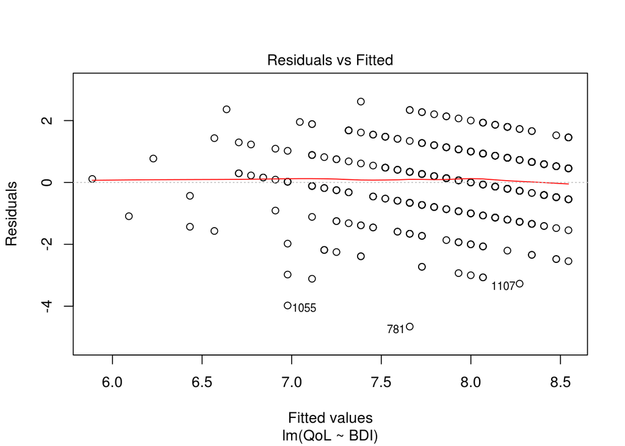

```r
#Diagnostics
plot(ov_mod, which=1)
```

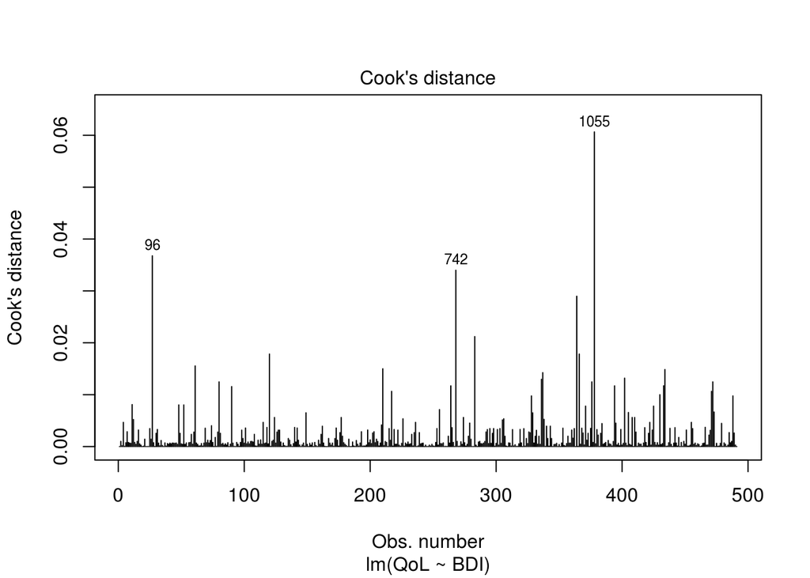

```r
cutoff <- 4/(ov_mod$df)
plot(ov_mod, which=4, cook.levels=cutoff)
```

Question Two

```r
#Initial correlations
vars <- c("MS.QoL", "DREEM.S.SP", "DREEM.A.SP", "Resilience", "BDI", "Age")
cor(clin[,vars], use="pairwise.complete.obs")
```

```
##                 MS.QoL  DREEM.S.SP  DREEM.A.SP Resilience         BDI
## MS.QoL      1.00000000  0.54744658  0.40488523  0.3175923 -0.40809301
## DREEM.S.SP  0.54744658  1.00000000  0.57218064  0.4257209 -0.52053588
## DREEM.A.SP  0.40488523  0.57218064  1.00000000  0.4819358 -0.32875516
## Resilience  0.31759228  0.42572085  0.48193583  1.0000000 -0.56656655
## BDI        -0.40809301 -0.52053588 -0.32875516 -0.5665665  1.00000000
## Age        -0.07208173 -0.04819259 -0.09025951  0.0401443 -0.02372227
##                    Age
## MS.QoL     -0.07208173
## DREEM.S.SP -0.04819259
## DREEM.A.SP -0.09025951
## Resilience  0.04014430
## BDI        -0.02372227
## Age         1.00000000
```

```r
#Test the initial correlations
library(psych)
corr.test(clin[,vars], use="pairwise.complete.obs")
```

```
## Call:corr.test(x = clin[, vars], use = "pairwise.complete.obs")
## Correlation matrix
##            MS.QoL DREEM.S.SP DREEM.A.SP Resilience   BDI   Age
## MS.QoL       1.00       0.55       0.40       0.32 -0.41 -0.07
## DREEM.S.SP   0.55       1.00       0.57       0.43 -0.52 -0.05
## DREEM.A.SP   0.40       0.57       1.00       0.48 -0.33 -0.09
## Resilience   0.32       0.43       0.48       1.00 -0.57  0.04
## BDI         -0.41      -0.52      -0.33      -0.57  1.00 -0.02
## Age         -0.07      -0.05      -0.09       0.04 -0.02  1.00
## Sample Size
## [1] 491
## Probability values (Entries above the diagonal are adjusted for multiple tests.)
##            MS.QoL DREEM.S.SP DREEM.A.SP Resilience BDI  Age
## MS.QoL       0.00       0.00       0.00       0.00 0.0 0.44
## DREEM.S.SP   0.00       0.00       0.00       0.00 0.0 0.86
## DREEM.A.SP   0.00       0.00       0.00       0.00 0.0 0.23
## Resilience   0.00       0.00       0.00       0.00 0.0 0.86
## BDI          0.00       0.00       0.00       0.00 0.0 0.86
## Age          0.11       0.29       0.05       0.37 0.6 0.00
##
##  To see confidence intervals of the correlations, print with the short=FALSE option
```

```r
#RQ2 Model
ms_mod <- lm(MS.QoL ~ DREEM.S.SP + DREEM.A.SP + Resilience + BDI + Age, data=clin)
summary(ms_mod)
```

```
##
## Call:
## lm(formula = MS.QoL ~ DREEM.S.SP + DREEM.A.SP + Resilience +
##     BDI + Age, data = clin)
##
## Residuals:
##     Min      1Q  Median      3Q     Max
## -4.5697 -0.7056  0.0725  0.8409  3.9567
##
## Coefficients:
##               Estimate Std. Error t value Pr(>|t|)
## (Intercept)  4.674e+00  7.650e-01   6.110 2.05e-09 ***
## DREEM.S.SP   1.394e-01  1.801e-02   7.739 5.87e-14 ***
## DREEM.A.SP   3.670e-02  1.428e-02   2.571 0.010439 *
## Resilience   4.345e-05  6.135e-03   0.007 0.994353
## BDI         -3.636e-02  1.067e-02  -3.409 0.000707 ***
## Age         -2.904e-02  2.352e-02  -1.235 0.217592
## ---
## Signif. codes:  0 '***' 0.001 '**' 0.01 '*' 0.05 '.' 0.1 ' ' 1
##
## Residual standard error: 1.229 on 485 degrees of freedom
## Multiple R-squared:  0.3337, Adjusted R-squared:  0.3269
## F-statistic: 48.59 on 5 and 485 DF,  p-value: < 2.2e-16
```

```r
confint(ms_mod)
```

```
##                    2.5 %      97.5 %
## (Intercept)  3.170622049  6.17671584
## DREEM.S.SP   0.103999969  0.17477991
## DREEM.A.SP   0.008652434  0.06475334
## Resilience  -0.012011893  0.01209879
## BDI         -0.057318060 -0.01540232
## Age         -0.075260330  0.01717907
```

```r
#Diagnostics
library(car)
vif(ms_mod)
```

```
## DREEM.S.SP DREEM.A.SP Resilience        BDI        Age
##   1.823375   1.698128   1.731791   1.737641   1.018183
```

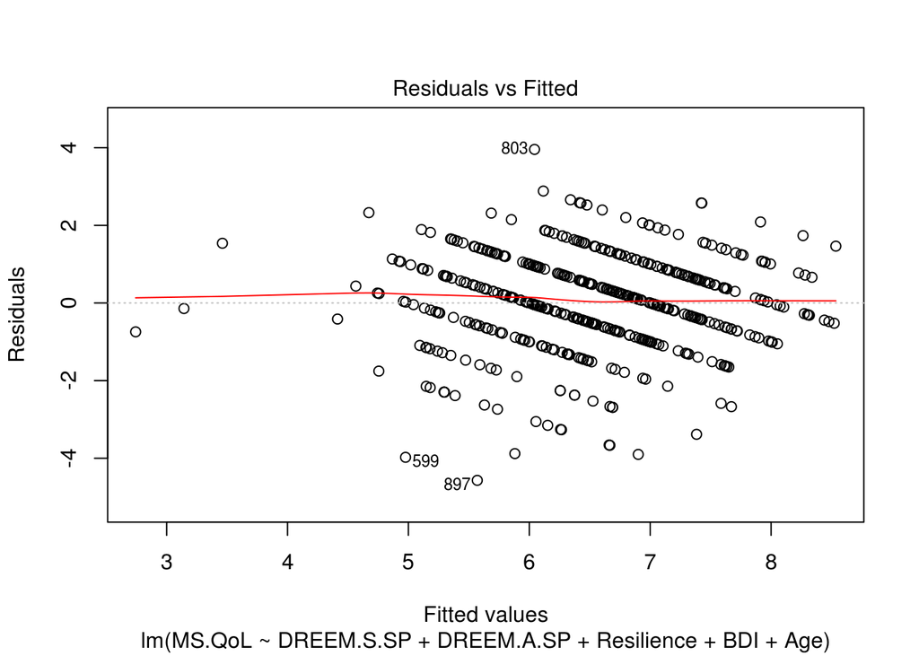

```r
plot(ms_mod, which=1)
```

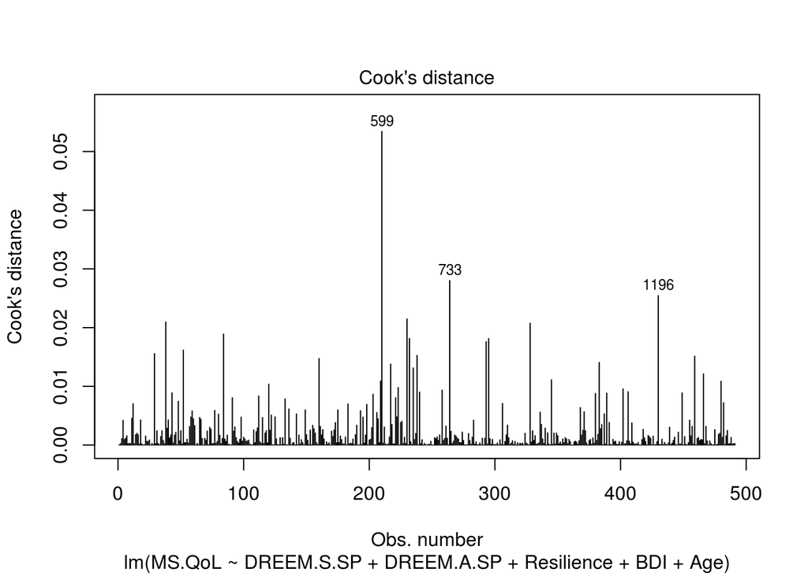

```r
cutoff <- 4/(ms_mod$df)
plot(ms_mod, which=4, cook.levels=cutoff)
```

```r
#Put model into context
lmBeta(ms_mod)
```

```
##    DREEM.S.SP    DREEM.A.SP    Resilience           BDI           Age
##  0.3873277406  0.1241752275  0.0003453895 -0.1665514046 -0.0461722487
```

```r
round(pCorr(ms_mod), 4)
```

```
##            Partial_Corr Partial_Corr_sq Part_Corr Part_Corr_sq
## DREEM.S.SP       0.3315          0.1099    0.2868       0.0823
## DREEM.A.SP       0.1160          0.0134    0.0953       0.0091
## Resilience       0.0003          0.0000    0.0003       0.0000
## BDI             -0.1530          0.0234   -0.1263       0.0160
## Age             -0.0560          0.0031   -0.0458       0.0021
```

problem 1/1 point (graded) 1. What does the summary() function do? provides the output from the linear model in the console correct shows the standardized betas of the model runs the linear model for the research question provides summary statistics for the outcome variable Submit You have used 1 of 1 attempt Some problems have options such as save, reset, hints, or show answer. These options follow the Submit button.

Show Answer Correct (1/1 point) Review problem 1/1 point (graded) 2. What is the purpose of the following code option in cor()?

use=“pairwise.complete.obs”

It is the option that shows the correlation matrix It shows the p-values associated with each correlation It allows for all complete data to be used in the correlations correct It calls the “pairwise.complete.obs” data set Submit You have used 1 of 1 attempt Some problems have options such as save, reset, hints, or show answer. These options follow the Submit button.

Show Answer Correct (1/1 point) Review problem 1/1 point (graded) 3. What kind of diagnostic plot is provided from the following code?

plot(ov_mod, which=1)

A Cook’s Distance plot A Q-Q plot for normality A scatterplot A Residuals vs. Fitted plot correct Submit You have used 1 of 1 attempt Some problems have options such as save, reset, hints, or show answer. These options follow the Submit button.

Show Answer Correct (1/1 point) Review problem 1/1 point (graded) 4. What does the function lmBeta() do? Provides the partial correlation coefficients for the model Provides the semi-partial (part) correlation coefficients for the model Provides the Standardized Betas for the model correct Runs all diagnostic plots Submit You have used 1 of 1 attempt Some problems have options such as save, reset, hints, or show answer. These options follow the Submit button.

Show Answer Correct (1/1 point) Review problem 1/1 point (graded) 5. You want to run a correlation matrix, and then get the p-value for each bivariate correlation. You run the following code. What caused the error?

vars <- c(‘MS.QoL’, ‘DREEM.S.SP’, ‘DREEM.A.SP’, ‘Resilience’, ‘BDI’, ‘Age’) cor.test(clin[,vars], use=“pairwise.complete.obs”)

Warning messages: Error in cor.test.default(clin[, vars], use = “pairwise.complete.obs”) : , argument “y” is missing, with no default

The function is called corr.test rather than cor.test correct A correlation matrix only has two variables, not six. The dataset “pairwise.complete.obs” is not provided. DREEM.S.SP is not the outcome varaible (y)

Primary Research Questions

1. Can you confirm the claim that Beck Depression Inventory score is a significant predictor of Overall Quality of Life among students enrolled in the Clinical Sciences program?
2. For students enrolled in the Clinical Sciences program, examine the effects of DREEM: Social Self Perception, DREEM: Academic Self Perception, Resilience, BDI, and Age on Med School Quality of Life?

Conduct the Analysis in R

1. Type or copy the script from the Prepare for the Analysis section into the Script window of R.
2. Select the portion of the code you wish to run, then press “ctrl+ enter.”
3. Output can be found in the Console window.

```r
#Subset into the Clinical Sciences
clin <- res[res$Group == "Clinical Sciences",]
```

Question One

```r
#Intial Correlations
vars <- c("QoL", "BDI")
cor(clin[,vars])
```

```
##            QoL        BDI
## QoL  1.0000000 -0.3746403
## BDI -0.3746403  1.0000000
```

```r
#RQ1 Model
ov_mod <- lm(QoL ~ BDI, data=clin)
summary(ov_mod)
```

```
##
## Call:
## lm(formula = QoL ~ BDI, data = clin)
##
## Residuals:
##     Min      1Q  Median      3Q     Max
## -4.6587 -0.6587  0.0687  0.7962  2.6138
##
## Coefficients:
##              Estimate Std. Error t value Pr(>|t|)
## (Intercept)  8.544521   0.088521  96.526   <2e-16 ***
## BDI         -0.068137   0.007626  -8.935   <2e-16 ***
## ---
## Signif. codes:  0 '***' 0.001 '**' 0.01 '*' 0.05 '.' 0.1 ' ' 1
##
## Residual standard error: 1.159 on 489 degrees of freedom
## Multiple R-squared:  0.1404, Adjusted R-squared:  0.1386
## F-statistic: 79.84 on 1 and 489 DF,  p-value: < 2.2e-16
```

```r
confint(ov_mod)
```

```
##                   2.5 %      97.5 %
## (Intercept)  8.37059347  8.71844843
## BDI         -0.08311937 -0.05315364
```

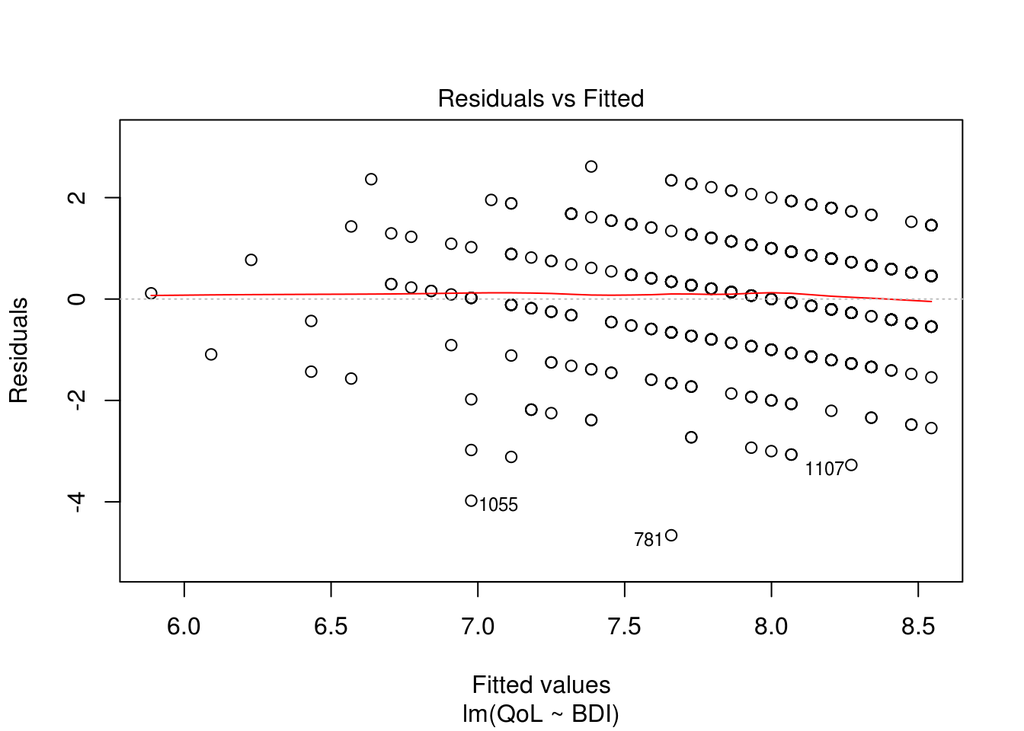

```r
#Diagnostics
plot(ov_mod, which=1)
```

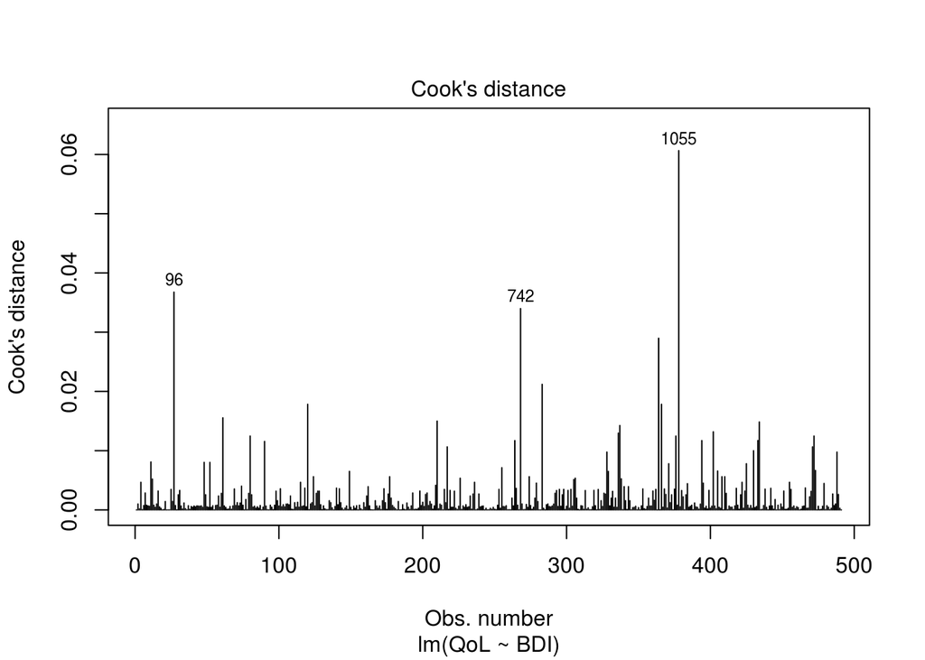

```r
cutoff <- 4/(ov_mod$df)
plot(ov_mod, which=4, cook.levels=cutoff)
```

Question Two

```r
#Initial correlations
vars <- c("MS.QoL", "DREEM.S.SP", "DREEM.A.SP", "Resilience", "BDI", "Age")
cor(clin[,vars], use="pairwise.complete.obs")
```

```
##                 MS.QoL  DREEM.S.SP  DREEM.A.SP Resilience         BDI
## MS.QoL      1.00000000  0.54744658  0.40488523  0.3175923 -0.40809301
## DREEM.S.SP  0.54744658  1.00000000  0.57218064  0.4257209 -0.52053588
## DREEM.A.SP  0.40488523  0.57218064  1.00000000  0.4819358 -0.32875516
## Resilience  0.31759228  0.42572085  0.48193583  1.0000000 -0.56656655
## BDI        -0.40809301 -0.52053588 -0.32875516 -0.5665665  1.00000000
## Age        -0.07208173 -0.04819259 -0.09025951  0.0401443 -0.02372227
##                    Age
## MS.QoL     -0.07208173
## DREEM.S.SP -0.04819259
## DREEM.A.SP -0.09025951
## Resilience  0.04014430
## BDI        -0.02372227
## Age         1.00000000
```

```r
#Test the initial correlations
library(psych)
corr.test(clin[,vars], use="pairwise.complete.obs")
```

```
## Call:corr.test(x = clin[, vars], use = "pairwise.complete.obs")
## Correlation matrix
##            MS.QoL DREEM.S.SP DREEM.A.SP Resilience   BDI   Age
## MS.QoL       1.00       0.55       0.40       0.32 -0.41 -0.07
## DREEM.S.SP   0.55       1.00       0.57       0.43 -0.52 -0.05
## DREEM.A.SP   0.40       0.57       1.00       0.48 -0.33 -0.09
## Resilience   0.32       0.43       0.48       1.00 -0.57  0.04
## BDI         -0.41      -0.52      -0.33      -0.57  1.00 -0.02
## Age         -0.07      -0.05      -0.09       0.04 -0.02  1.00
## Sample Size
## [1] 491
## Probability values (Entries above the diagonal are adjusted for multiple tests.)
##            MS.QoL DREEM.S.SP DREEM.A.SP Resilience BDI  Age
## MS.QoL       0.00       0.00       0.00       0.00 0.0 0.44
## DREEM.S.SP   0.00       0.00       0.00       0.00 0.0 0.86
## DREEM.A.SP   0.00       0.00       0.00       0.00 0.0 0.23
## Resilience   0.00       0.00       0.00       0.00 0.0 0.86
## BDI          0.00       0.00       0.00       0.00 0.0 0.86
## Age          0.11       0.29       0.05       0.37 0.6 0.00
##
##  To see confidence intervals of the correlations, print with the short=FALSE option
```

```r
#RQ2 Model
ms_mod <- lm(MS.QoL ~ DREEM.S.SP + DREEM.A.SP + Resilience + BDI + Age, data=clin)
summary(ms_mod)
```

```
##
## Call:
## lm(formula = MS.QoL ~ DREEM.S.SP + DREEM.A.SP + Resilience +
##     BDI + Age, data = clin)
##
## Residuals:
##     Min      1Q  Median      3Q     Max
## -4.5697 -0.7056  0.0725  0.8409  3.9567
##
## Coefficients:
##               Estimate Std. Error t value Pr(>|t|)
## (Intercept)  4.674e+00  7.650e-01   6.110 2.05e-09 ***
## DREEM.S.SP   1.394e-01  1.801e-02   7.739 5.87e-14 ***
## DREEM.A.SP   3.670e-02  1.428e-02   2.571 0.010439 *
## Resilience   4.345e-05  6.135e-03   0.007 0.994353
## BDI         -3.636e-02  1.067e-02  -3.409 0.000707 ***
## Age         -2.904e-02  2.352e-02  -1.235 0.217592
## ---
## Signif. codes:  0 '***' 0.001 '**' 0.01 '*' 0.05 '.' 0.1 ' ' 1
##
## Residual standard error: 1.229 on 485 degrees of freedom
## Multiple R-squared:  0.3337, Adjusted R-squared:  0.3269
## F-statistic: 48.59 on 5 and 485 DF,  p-value: < 2.2e-16
```

```r
confint(ms_mod)
```

```
##                    2.5 %      97.5 %
## (Intercept)  3.170622049  6.17671584
## DREEM.S.SP   0.103999969  0.17477991
## DREEM.A.SP   0.008652434  0.06475334
## Resilience  -0.012011893  0.01209879
## BDI         -0.057318060 -0.01540232
## Age         -0.075260330  0.01717907
```

```r
#Diagnostics
library(car)
vif(ms_mod)
```

```
## DREEM.S.SP DREEM.A.SP Resilience        BDI        Age
##   1.823375   1.698128   1.731791   1.737641   1.018183
```

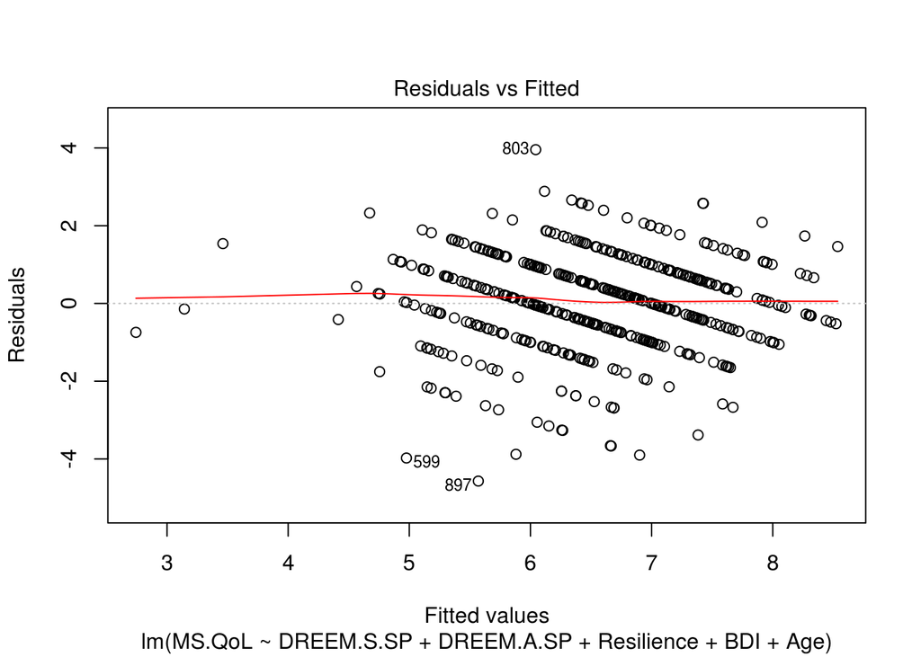

```r
plot(ms_mod, which=1)
```

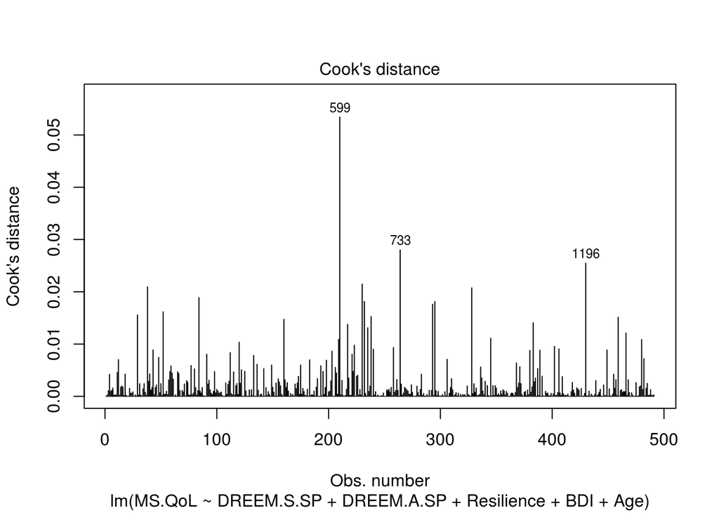

```r
cutoff <- 4/(ms_mod$df)
plot(ms_mod, which=4, cook.levels=cutoff)
```

```r
#Put model into context
lmBeta(ms_mod)
```

```
##    DREEM.S.SP    DREEM.A.SP    Resilience           BDI           Age
##  0.3873277406  0.1241752275  0.0003453895 -0.1665514046 -0.0461722487
```

```r
round(pCorr(ms_mod), 4)
```

```
##            Partial_Corr Partial_Corr_sq Part_Corr Part_Corr_sq
## DREEM.S.SP       0.3315          0.1099    0.2868       0.0823
## DREEM.A.SP       0.1160          0.0134    0.0953       0.0091
## Resilience       0.0003          0.0000    0.0003       0.0000
## BDI             -0.1530          0.0234   -0.1263       0.0160
## Age             -0.0560          0.0031   -0.0458       0.0021
```

problem 2/2 points (graded) Research Question 1:

1a) What is the inital correlation coefficient between overall Quality of Life and Beck Depression Inventory? (Round to three decimal places.)

-0.375 correct −0.375 1b) What is the t-value of the Simple Regression slope for Beck Depression Inventory? (Round to three decimal places.)

-8.935 correct −8.935 Submit You have used 1 of 1 attempt Some problems have options such as save, reset, hints, or show answer. These options follow the Submit button.

Show Answer Correct (2/2 points) Review problem 3/3 points (graded) Research Question 2:

2a) What is the R-squared value for the overall model? (Report as a percentage, and round to 2 decimal places.)

33.37 correct 33.37 2b) What is the Adjusted R-squared for the overall model? (Report as a percentage, and round to 2 decimal places.)

32.69 correct 32.69 2c) What is the F-value for the overall model? (Round to 2 decimal places.)

48.59 correct 48.59 Submit You have used 1 of 1 attempt Some problems have options such as save, reset, hints, or show answer. These options follow the Submit button.

Show Answer Correct (3/3 points) Review problem 4/4 points (graded) Research Question 2:

3a) The Standardized Beta for DREEM Social Self Perception is (Round to three decimal places):

0.387 correct

3b) This means that as DREEM Social Self Perception increases by ______ standard deviation(s), the outcome of Med School Quality of Life increases by ______(Round to three decimal places):

1 correct

0.387 correct

3c) What amount of unique variance can be accounted for in the model by DREEM Social Self Perception? (Report as a percentage and round to two decimal places.)

8.23 correct

Submit You have used 1 of 1 attempt Some problems have options such as save, reset, hints, or show answer. These options follow the Submit button.

Show Answer Correct (4/4 points) Review problem 1/1 point (graded) Research Question 2:

4. According to the results from the full Multiple Regression Model, what is the best predictor of Med School Quality of Life, among Clinical Science students?

BDI DREEM Social Self Perception correct DREEM Academinc Self Perception Resilience

Primary Research Questions

1. Can you confirm the claim that Beck Depression Inventory score is a significant predictor of Overall Quality of Life among students enrolled in the Clinical Sciences program?
2. For students enrolled in the Clinical Sciences program, examine the effects of DREEM: Social Self Perception, DREEM: Academic Self Perception, Resilience, BDI, and Age on Med School Quality of Life?

problem 9/10 points (graded) Write Your Conclusion

Answer the question and support your answer with statistics:

To answer our primary research questions about Clinical Sciences med students, we conducted two primary tests: a simple linear regression and a multiple linear regression. First, we investigated the claimed effect of Beck Depression Inventory score on Overall Quality of Life. There was a correctnegative correlation between Beck Depression Inventory score and Overall Quality of Life. The corresponding model showed a incorrectsignificant simple slope for Beck Depression Inventory (t(489)= correct-8.935 , p<0.05) indicating that as the Beck Depression Inventory score increases, the Overall Quality of Life score correctdecreases

The multiple linear regression examined the impact of DREEM: Social Self Perception, DREEM: Academic Self Perception, Resilience, BDI, and Age on Med School Quality of Life. Overall, the model was correctsignificant (F(5,485)= correct48.59 , p<.05), and could account for correct33.37% of the variance in the outcome (Adjusted R2= correct32.69% ). The best predictor of Med School Quality of Life was correctDREEM: Social Self Perception which could account for a unique proportion of variance in the outcome of correct8.23%.

# LAB 6: MEDICAL SCHOOL QUALITY OF LIFE

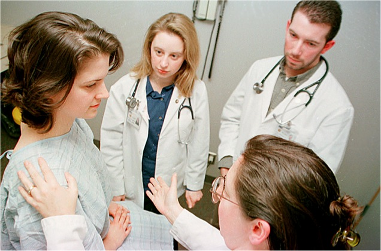

In a 2015 study, Tempski and associates examined a measurement they called Quality of Life among medical school students in Brazilian medical schools. They borrowed measurement scales from the World Health Organization, the Dundee Ready Education Environment Scale, and the Beck Depression Inventory to assess the dependent variable in potential relation to a number of predictor variables.

problem 1/2 points (graded) Review of Regression Analysis

In this lab, you will use Regression Analysis to answer a question of interest. Let’s start by remembering why we use Multiple Linear Regression Analysis.

1a. In a Multiple Linear Regression model, not only can we compare overall model fit, but for each predictor we can also find the ______.

slope and significance correct simple regression value Pearson Correlation incorrect Cook’s Distance 1b. Which measure, asked for after we run our Multiple Linear Regression model, tells us the unique proportion of variance accounted for by each predictor?

the multiple R-squared value the part (or semi-partial) correlation squared value correct the standardized beta values the standardized beta values, squared Submit You have used 1 of 1 attempt Some problems have options such as save, reset, hints, or show answer. These options follow the Submit button.

Show Answer Answers are displayed within the problem Review problem 1/1 point (graded) Lab Preparation

In this lab you will be working with the Tempski et al. data on Brazilian medical students.

1. Open RStudio. Make sure you’ve installed the SDSFoundations package.
2. Type library(SDSFoundations). This will automatically load the data for the labs. 3.Type res <- TempskiResilience. This will assign the data to your Workspace.

Alternatively, you can use the steps in the “Importing a Data Frame” R tutorial video, and use the TempskiResilience.csv file. (Right-click and “Save As.”) Make sure to name the dataframe “res” when importing.

1. Open RStudio.
2. Click on the “Import Dataset” button at the top of the workspace window. Choose “from text file.”
3. Click on the location of the TempskiResilience.csv file you just downloaded.
4. Click on the TempskiResilience.csv file. Then, click Upload.

Feel free to use the script from the week’s PreLab, which you can modify for use in this Lab.

2. Two of the following questions will be answered in this lab using Linear Regression. Select the questions that can be answered with this method.

Of the four measures of Quality of Life (Physical Health, Psychological, Social Relationships, and Environment), which has the greatest impact on Med School Quality of Life? What is the overall proportion of varaince explained by the predictors in the model? Can program selection group be predicted by Quality of Life and Resilience? correct

PRIMARY RESEARCH QUESTIONS

1. For students in the Basic Sciences program, of the four measures of Quality of Life (Physical Health, Psychological, Social Relationships, and Environment), which has the greatest impact on Med School Quality of Life?
2. What is the overall proportion of variance accounted for by all four scales?

ANALYSIS

Let’s break this question down into the different descriptive statistics that you will need to construct your answer. Be sure that your R output includes all of the following components.

To answer both lab questions:

1. Subset the data for students in the Basic Sciences Program.
2. Determine the variables of interest and the outcome variable.
3. Run a Multiple Linear Regression.
4. Find the Standardized Betas for the coefficients using lmBeta().
5. Use pCorr() to find the partial and part correlations.

```r
library(SDSFoundations)

res <- TempskiResilience
```

```r
#Subset into the Clinical Sciences
basic <- res[res$Group == "Basic Sciences",]
```

Question Two

```r
#Initial correlations
vars <- c("MS.QoL", "WHOQOL.PH", "WHOQOL.PSY", "WHOQOL.SOC", "WHOQOL.ENV")
cor(basic[,vars], use="pairwise.complete.obs")
```

```
##               MS.QoL WHOQOL.PH WHOQOL.PSY WHOQOL.SOC WHOQOL.ENV
## MS.QoL     1.0000000 0.4606006  0.5084537  0.3574410  0.4410060
## WHOQOL.PH  0.4606006 1.0000000  0.7004893  0.4181263  0.5430001
## WHOQOL.PSY 0.5084537 0.7004893  1.0000000  0.5660826  0.5374479
## WHOQOL.SOC 0.3574410 0.4181263  0.5660826  1.0000000  0.4311870
## WHOQOL.ENV 0.4410060 0.5430001  0.5374479  0.4311870  1.0000000
```

```r
#Test the initial correlations
library(psych)
corr.test(basic[,vars], use="pairwise.complete.obs")
```

```
## Call:corr.test(x = basic[, vars], use = "pairwise.complete.obs")
## Correlation matrix
##            MS.QoL WHOQOL.PH WHOQOL.PSY WHOQOL.SOC WHOQOL.ENV
## MS.QoL       1.00      0.46       0.51       0.36       0.44
## WHOQOL.PH    0.46      1.00       0.70       0.42       0.54
## WHOQOL.PSY   0.51      0.70       1.00       0.57       0.54
## WHOQOL.SOC   0.36      0.42       0.57       1.00       0.43
## WHOQOL.ENV   0.44      0.54       0.54       0.43       1.00
## Sample Size
## [1] 459
## Probability values (Entries above the diagonal are adjusted for multiple tests.)
##            MS.QoL WHOQOL.PH WHOQOL.PSY WHOQOL.SOC WHOQOL.ENV
## MS.QoL          0         0          0          0          0
## WHOQOL.PH       0         0          0          0          0
## WHOQOL.PSY      0         0          0          0          0
## WHOQOL.SOC      0         0          0          0          0
## WHOQOL.ENV      0         0          0          0          0
##
##  To see confidence intervals of the correlations, print with the short=FALSE option
```

```r
#RQ2 Model
mlr_model <- lm(MS.QoL ~ WHOQOL.PH + WHOQOL.PSY + WHOQOL.SOC + WHOQOL.ENV, data=basic)
summary(mlr_model)
```

```
##
## Call:
## lm(formula = MS.QoL ~ WHOQOL.PH + WHOQOL.PSY + WHOQOL.SOC + WHOQOL.ENV,
##     data = basic)
##
## Residuals:
##     Min      1Q  Median      3Q     Max
## -4.7116 -0.7307  0.1265  0.8432  3.6141
##
## Coefficients:
##             Estimate Std. Error t value Pr(>|t|)
## (Intercept) 2.466823   0.307790   8.015 9.43e-15 ***
## WHOQOL.PH   0.013953   0.005683   2.455   0.0145 *
## WHOQOL.PSY  0.026523   0.005957   4.452 1.07e-05 ***
## WHOQOL.SOC  0.005132   0.003975   1.291   0.1974
## WHOQOL.ENV  0.020544   0.005231   3.927 9.94e-05 ***
## ---
## Signif. codes:  0 '***' 0.001 '**' 0.01 '*' 0.05 '.' 0.1 ' ' 1
##
## Residual standard error: 1.303 on 454 degrees of freedom
## Multiple R-squared:  0.3097, Adjusted R-squared:  0.3036
## F-statistic: 50.91 on 4 and 454 DF,  p-value: < 2.2e-16
```

```r
confint(mlr_model)
```

```
##                    2.5 %     97.5 %
## (Intercept)  1.861952663 3.07169272
## WHOQOL.PH    0.002783990 0.02512173
## WHOQOL.PSY   0.014815880 0.03823099
## WHOQOL.SOC  -0.002679993 0.01294414
## WHOQOL.ENV   0.010262915 0.03082428
```

```r
#Diagnostics
library(car)
vif(mlr_model)
```

```
##  WHOQOL.PH WHOQOL.PSY WHOQOL.SOC WHOQOL.ENV
##   2.126661   2.459209   1.522653   1.573503
```

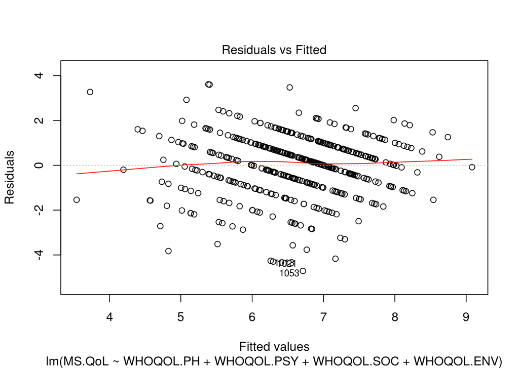

```r
plot(mlr_model, which=1)
```

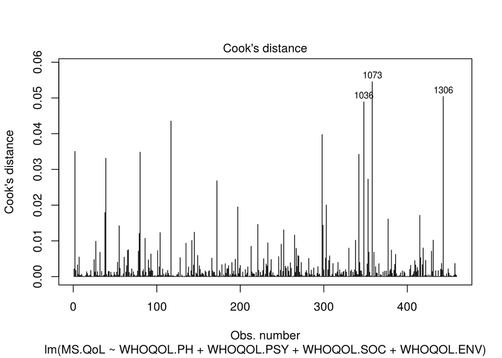

```r
cutoff <- 4/(mlr_model$df)
plot(mlr_model, which=4, cook.levels=cutoff)
```

```r
#Put model into context
lmBeta(mlr_model)
```

```
##  WHOQOL.PH WHOQOL.PSY WHOQOL.SOC WHOQOL.ENV
## 0.13961019 0.27225462 0.06212142 0.19208898
```

```r
round(pCorr(mlr_model), 4)
```

```
##            Partial_Corr Partial_Corr_sq Part_Corr Part_Corr_sq
## WHOQOL.PH        0.1145          0.0131    0.0957       0.0092
## WHOQOL.PSY       0.2045          0.0418    0.1736       0.0301
## WHOQOL.SOC       0.0605          0.0037    0.0503       0.0025
## WHOQOL.ENV       0.1813          0.0329    0.1531       0.0234
```

problem 4/4 points (graded) Provide the intitial bivariate Pearson Correlation Coefficients for the following variables and the outcome of Med School Quality of Life. Round to 4 decimal places:

1a. Physical Health QoL

0.4606 correct 0.4606 1b. Psychological QoL

0.5085 correct 0.5085 1c. Social Relationships QoL

0.3574 correct 0.3574 1d. Environment QoL

0.4410 correct 0.4410 Submit You have used 1 of 1 attempt Some problems have options such as save, reset, hints, or show answer. These options follow the Submit button.

Show Answer Correct (4/4 points) Review problem 4/4 points (graded) Provide the t-statistic for the predictors in the Multiple Linear Regression for the following variables predicting Med School Quality of Life. Round to 3 decimal places:

2a. Physical Health QoL

2.455 correct 2.455 2b. Psychological QoL

4.452 correct 4.452 2c. Social Relationships QoL

1.291 correct 1.291 2d. Environment QoL

3.927 correct 3.927 Submit You have used 1 of 1 attempt Some problems have options such as save, reset, hints, or show answer. These options follow the Submit button.

Show Answer Correct (4/4 points) Review problem 2/2 points (graded) What are the Overall Model statistics for the prediction of Med School Quality of life?

3a. Overall Model F-value (Round to 2 decimal places.)

50.91 correct 50.91 3b. Overall Model R-squared (Round to 4 decimal places)

0.3097 correct 0.3097 Submit You have used 1 of 1 attempt Some problems have options such as save, reset, hints, or show answer. These options follow the Submit button.

Show Answer Correct (2/2 points) Review problem 2/2 points (graded) 4a. Which of the following coefficeints in the model would be considered the best predictor of Med School Quality of Life? Physical Health QoL Psychological QoL correct Social Relationships QoL Environment QoL 4b. What is the amount of unique proportion of variance accounted for in the prediction of Med School Quality of Life by the best predictor (the correct answer above)? 0.2% 0.9% 2.3% 3.0% correct

PRIMARY RESEARCH QUESTIONS

1. For students in the Basic Sciences program, of the four measures of Quality of Life (Physical Health, Psychological, Social Relationships, and Environment), which has the greatest impact on Med School Quality of Life?
2. What is the overall proportion of variance accounted for by all four scales?

problem 7/7 points (graded) Write Your Conclusion

Answer the question and support your answer with statistics:

Our primary research question investigated the predictive impact of several Quality of Life items (Physical Health, Psychological, Social Relationships, and Environment) on the outcome of Med School Quality of Life score for Basic Sciences enrolled students. The model showed a correctSignificant overall effect (F(4, 454) = correct50.91 , p<0.05), The four predictor variables accounted for correct30.97 percent of the variance in the outcome of Med School Quality of Life. The best predictor of Med School Quality of Life was the Psychological QoL scale (t(454) = correct4.452 , p<0.05). As Psychological QoL scale increases one unit, Med School Quality of Life increased by correct0.0265 (Standardized beta = correct0.2723 Although significant, and the best predictor in the model, Psychological QoL could only uniquely account for correct3.0% of the variance in the outcome. .

# Problem Set

Question 1 Bookmark this page Answer the following research question using multiple regression on the Timpskey et al. dataset:

For clinical science students, after controlling for Gender and Age, what predictor has a greater impact on BDI score - State or Trait anxiety?

Use the results to answer the following questions.

```r
#Initial correlations
names(clin)
```

```
##  [1] "IDR"                 "Female"              "Group"
##  [4] "QoL"                 "MS.QoL"              "WHOQOL.PH"
##  [7] "WHOQOL.PSY"          "WHOQOL.SOC"          "WHOQOL.ENV"
## [10] "DREEM.L"             "DREEM.T"             "DREEM.A.SP"
## [13] "DREEM.At"            "DREEM.S.SP"          "DREEM.GS"
## [16] "Resilience"          "BDI"                 "Age"
## [19] "School.legal.status" "School.location"     "State.Anxiety"
## [22] "Trait.anxiety"
```

```r
vars <- c("Female", "Age", "BDI", "State.Anxiety", "Trait.anxiety")
cor(clin[,vars], use="pairwise.complete.obs")
```

```
##                   Female          Age         BDI State.Anxiety
## Female         1.0000000 -0.073885300  0.11068414    0.10692940
## Age           -0.0738853  1.000000000 -0.02372227    0.04624304
## BDI            0.1106841 -0.023722268  1.00000000    0.58191934
## State.Anxiety  0.1069294  0.046243040  0.58191934    1.00000000
## Trait.anxiety  0.1820127  0.001918579  0.72265204    0.67339885
##               Trait.anxiety
## Female          0.182012744
## Age             0.001918579
## BDI             0.722652043
## State.Anxiety   0.673398845
## Trait.anxiety   1.000000000
```

```r
#Test the initial correlations
library(psych)
corr.test(clin[,vars], use="pairwise.complete.obs")
```

```
## Call:corr.test(x = clin[, vars], use = "pairwise.complete.obs")
## Correlation matrix
##               Female   Age   BDI State.Anxiety Trait.anxiety
## Female          1.00 -0.07  0.11          0.11          0.18
## Age            -0.07  1.00 -0.02          0.05          0.00
## BDI             0.11 -0.02  1.00          0.58          0.72
## State.Anxiety   0.11  0.05  0.58          1.00          0.67
## Trait.anxiety   0.18  0.00  0.72          0.67          1.00
## Sample Size
## [1] 491
## Probability values (Entries above the diagonal are adjusted for multiple tests.)
##               Female  Age  BDI State.Anxiety Trait.anxiety
## Female          0.00 0.41 0.08          0.09             0
## Age             0.10 0.00 1.00          0.92             1
## BDI             0.01 0.60 0.00          0.00             0
## State.Anxiety   0.02 0.31 0.00          0.00             0
## Trait.anxiety   0.00 0.97 0.00          0.00             0
##
##  To see confidence intervals of the correlations, print with the short=FALSE option
```

```r
#RQ2 Model
q1_mod <- lm(BDI ~ Female + Age + State.Anxiety + Trait.anxiety, data=clin)
summary(q1_mod)
```

```
##
## Call:
## lm(formula = BDI ~ Female + Age + State.Anxiety + Trait.anxiety,
##     data = clin)
##
## Residuals:
##     Min      1Q  Median      3Q     Max
## -13.790  -3.066  -0.463   2.574  17.989
##
## Coefficients:
##               Estimate Std. Error t value Pr(>|t|)
## (Intercept)   -9.46801    2.21954  -4.266 2.40e-05 ***
## Female        -0.29346    0.43087  -0.681    0.496
## Age           -0.09978    0.08901  -1.121    0.263
## State.Anxiety  0.10554    0.02491   4.236 2.72e-05 ***
## Trait.anxiety  0.36928    0.02558  14.438  < 2e-16 ***
## ---
## Signif. codes:  0 '***' 0.001 '**' 0.01 '*' 0.05 '.' 0.1 ' ' 1
##
## Residual standard error: 4.673 on 486 degrees of freedom
## Multiple R-squared:  0.5404, Adjusted R-squared:  0.5366
## F-statistic: 142.8 on 4 and 486 DF,  p-value: < 2.2e-16
```

```r
confint(q1_mod)
```

```
##                      2.5 %      97.5 %
## (Intercept)   -13.82909413 -5.10693523
## Female         -1.14005716  0.55314272
## Age            -0.27467086  0.07511655
## State.Anxiety   0.05659273  0.15449366
## Trait.anxiety   0.31902962  0.41953852
```

```r
#Diagnostics
library(car)
vif(q1_mod)
```

```
##        Female           Age State.Anxiety Trait.anxiety
##      1.040493      1.009293      1.837033      1.873112
```

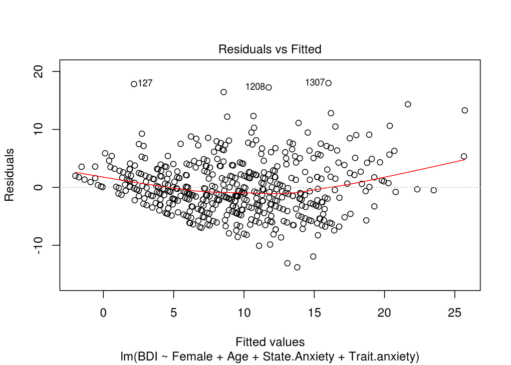

```r
plot(q1_mod, which=1)
```

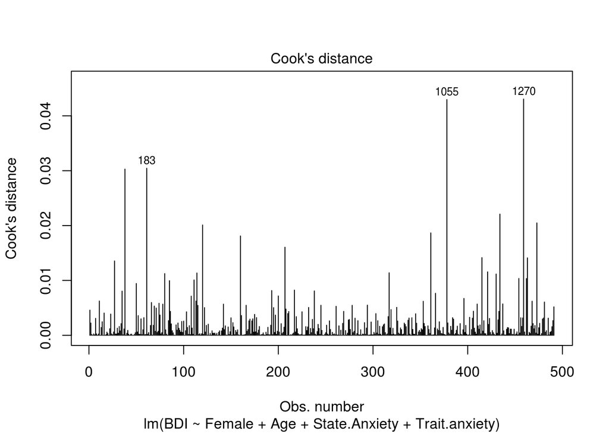

```r
cutoff <- 4/(q1_mod$df)
plot(q1_mod, which=4, cook.levels=cutoff)
```

```r
#Put model into context
lmBeta(q1_mod)
```

```
##        Female           Age State.Anxiety Trait.anxiety
##   -0.02136509   -0.03463251    0.17658362    0.60769600
```

```r
round(pCorr(q1_mod), 4)
```

```
##               Partial_Corr Partial_Corr_sq Part_Corr Part_Corr_sq
## Female             -0.0309          0.0010   -0.0209       0.0004
## Age                -0.0508          0.0026   -0.0345       0.0012
## State.Anxiety       0.1887          0.0356    0.1303       0.0170
## Trait.anxiety       0.5479          0.3002    0.4440       0.1972
```

problem 0/3 points (graded) After running the full model, with all predictors:

1a. What was the overall model fit (R-squared value)? Report as a percentage and round to 2 decimal places.

Show Answer Answers are displayed within the problem Review problem 2/2 points (graded) 1d. What was the Standardized Beta score for State Anxiety? Round to 3 decimal places.

0.177 correct 0.177 1e. What was the Standardized Beta score for Trait Anxiety? Round to 3 decimal places.

0.608 correct 0.608 Submit You have used 1 of 1 attempt Some problems have options such as save, reset, hints, or show answer. These options follow the Submit button.

Show Answer Correct (2/2 points) Review problem 1/2 points (graded) 1f. What was the proportion of variance that State Anxiety could uniquely account for in the prediction of BDI? Report as a percentage and round to 2 decimal places.

1.70 correct1.70 1.70 1g. What was the proportion of varaince that Trait Anxiety could uniquely account for in the prediction of BDI? Report as a percentage and round to 2 decimal places.

Show Answer Answers are displayed within the problem Review problem 1/1 point (graded) 1h. After controlling for Age and Gender, what was the best predictor of BDI? State Anxiety Trait Anxiety correct Both Neither

Question 2

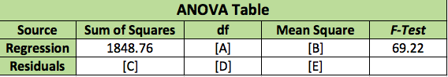

problem 0/1 point (graded) 2a) A=

19 incorrect1 19 Submit You have used 1 of 1 attempt Some problems have options such as save, reset, hints, or show answer. These options follow the Submit button.

Show Answer Answers are displayed within the problem Review problem 1/1 point (graded) 2b. B= (Round to 2 decimal places.)

1848.76 correct 1848.76 Submit You have used 1 of 1 attempt Some problems have options such as save, reset, hints, or show answer. These options follow the Submit button.

Show Answer Correct (1/1 point) Review problem 0/1 point (graded) 2c. C= (Round to 2 decimal places. Please do not use rounded values in your calculation.)

507.46 incorrect480.75 507.46 Submit You have used 1 of 1 attempt Some problems have options such as save, reset, hints, or show answer. These options follow the Submit button.

Show Answer Answers are displayed within the problem Review problem 0/1 point (graded) 2d. D=

19 incorrect18 19 Submit You have used 1 of 1 attempt Some problems have options such as save, reset, hints, or show answer. These options follow the Submit button.

Show Answer Answers are displayed within the problem Review problem 1/1 point (graded) 2e. E= (Round to 2 decimal places.)

26.71 correct 26.71 Submit You have used 1 of 1 attempt Some problems have options such as save, reset, hints, or show answer. These options follow the Submit button.

Show Answer Correct (1/1 point) Review problem 0/1 point (graded) 2f. F= (Round to 2 decimal places.)

-3.70 incorrect-1.84 −3.70 Submit You have used 1 of 1 attempt Some problems have options such as save, reset, hints, or show answer. These options follow the Submit button.

Show Answer Answers are displayed within the problem Review problem 0/1 point (graded) 2g. G= (Round to 2 decimal places.)

-3.70 incorrect1.27 −3.70 Submit You have used 1 of 1 attempt Some problems have options such as save, reset, hints, or show answer. These options follow the Submit button.

Show Answer Answers are displayed within the problem Review problem 0/1 point (graded) 2h. H= (Round to 4 decimal places. Use your rounded values from above.)

0 incorrect0.7936 0

Question 3

The tables below show the regression output of a multiple regression model relating the beginning salaries in dollars of employees in a given company to the following predictor variables:

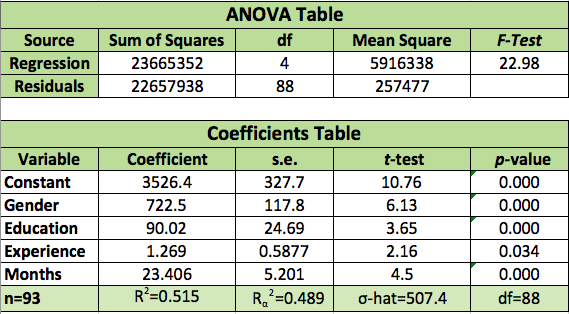

Gender An indicator variable (1=man and 0=woman) Education Years of schooling at the time of hire Experience Number of months of previous work experience Months Number of months with the company

problem 2/2 points (graded) 3a. What is the F-statistic for the overall fit of the regression (at a .05 level of significance)?

22.98 correct 22.98 3b. We should

Show Answer Correct (2/2 points) Review problem 1/1 point (graded) 3c. Is there a positive linear relationship between Salary and Experience, after accounting for the effect of the variables of Gender, Education, and Months?

correct Submit You have used 1 of 1 attempt Some problems have options such as save, reset, hints, or show answer. These options follow the Submit button.

Show Answer Correct (1/1 point) Review problem 2/2 points (graded) 3d. What salary would you forecast for a man with 12 years of education, 10 months of experience, and 15 months with the company? (Round to the nearest dollar - whole number.)

5692 correct 5692 3e. What salary would you forecast for a woman with 12 years of education, 10 months of experience, and 15 months with the company? (Round to the nearest dollar - whole number.)

4970 correct 4970